# 5. ggplot2 (Histogram)

Masahiko Asano

2026-07-23

- **`R packages` used in this section**

```r
library(DT)
library(gapminder)
library(gghighlight)
library(ggrepel)
library(stargazer)
library(tidyverse)
```

# 1. Histogram

- A histogram is an approximate representation of the distribution of **numerical data**.

#### Diffenece between a barchart and a histogram

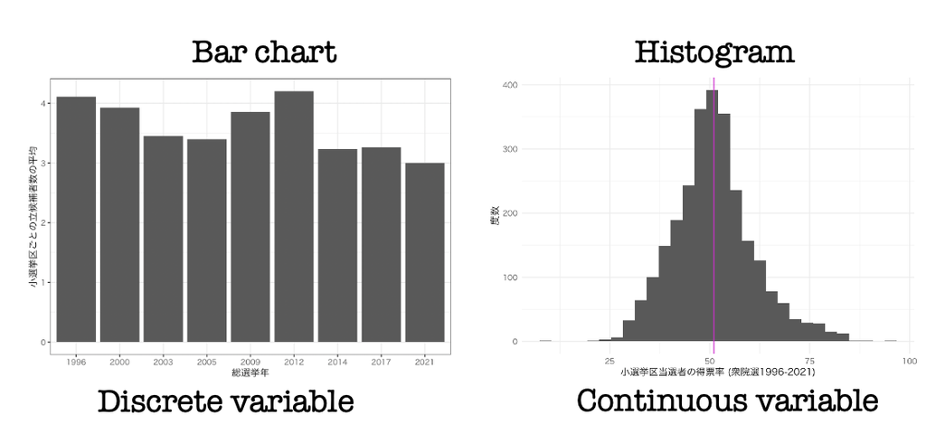

| Variable types | How to visualize | Feature |
| --- | --- | --- |
| Discrete variable | **Bar chart** | Lines between bars |
| Continuous variable | **Histogram** | No Lines between bars |

##### When `x-axis` is year of elections

- There is no values between 2017 and 2021 (because there was no election held between them)
- Years of election look like numeric, but it is not treated as `numeric`

##### When `x-axis` is vote share

- The value of vote share ranges from 0%, 0.1%, …. to 100%  
  → We need infinite number of bars for each value  
  → We do not use bars for each value
- We use limited number of bars

# 2. How to draw a histogram using ggplot2

## 2.1 Draw a simple histogram

- Make a folder, named `data` in your R Project folder
- Download hr96-26.csv onto the `data` folder in your R Project
- Read the election data, `hr96-26.csv` and name it `df`

```r
df <- read_csv("data/hr96-26.csv",
               na = ".")
```

- Using `if_else()`, make a dummy variable: `ldp`

##### **`mutate(ldp = if_else(seito == "自民", "LDP", "Non-LDP")`**

- This command means make a dummy variable, named `ldp`
- If a value in variable `seito` is “自民”, then replace it with “LDP” and replace the other values (that is, the other party names) in `seito` with “Non-LDP”

```r
df <- df %>%
  mutate(ldp = if_else(seito == "自民", "LDP", "Non-LDP"))
```

- Draw a histogram of vote share

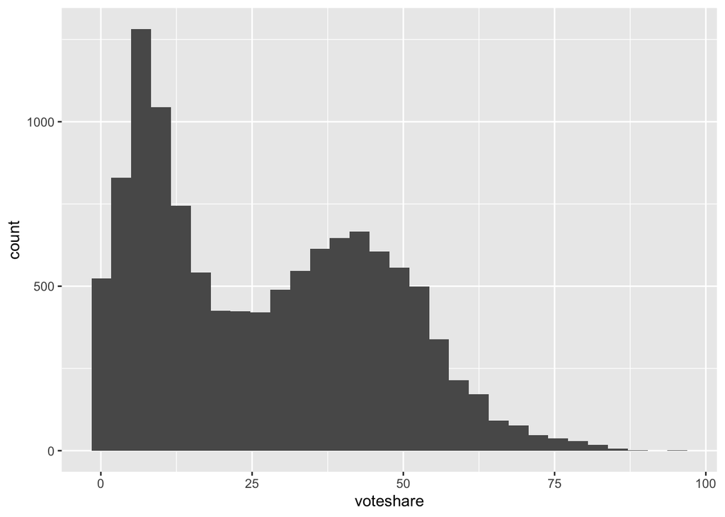

```r
df %>%
  ggplot() +
  geom_histogram(aes(x = voteshare))
```

## 2.2 What is a good histogram?

- A good histogram clearly address the following questions:
1. What is the the number of peaks in distribution?
2. If you have peaks, where is most densely (frequently) populated?
- You need to adjust the number of bins to show an appropriate histogram
- Which one is the best histogram among the following three histograms?
- Usually, a histogram does not have lines between bars, let me add white lines here.

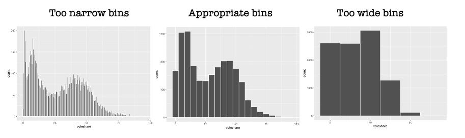

- The histogram in the left shows two peaks but it has too narrow bins
- The histogram in the right has too wide bins and we fail to see the two peaks
- The histogram in the middle has an appropriate width showing two peaks
- If you have too narrow bins (such as the one in the left), then **you show too much information in the histogram**
- If you have too wide bins (such as the one in the right), then **you might lose some important information data contains**
- **You need to choose an appripriate size of bins**

##### How to customize the number of bins:

- You can customize **the number of bins** using `bins = XX`

##### How to customize the width of bins:

- You can customize **the width of bins** using `binwidth = XX`

##### How to customize colors

- By adding lines between bins, you can make your histogram way easier to see.
- You can customize the color (such as `color = "white"`) out of `aes()` and within `geom_histogram()`

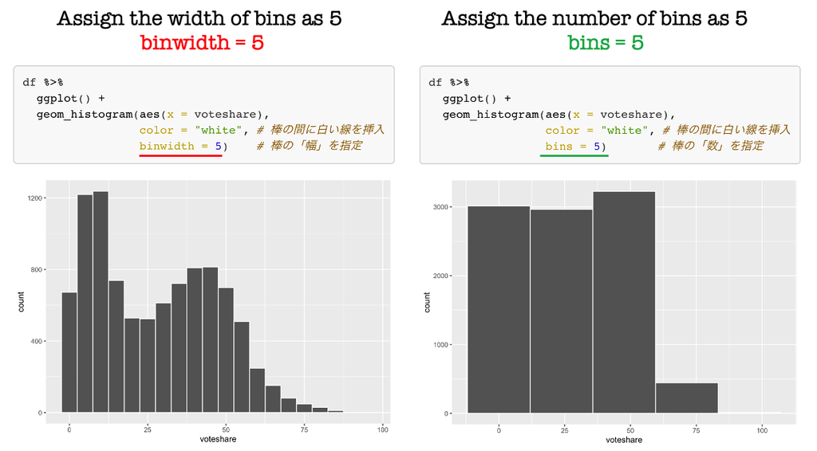

bin and binwidth ・You can customize either **`binwidth`** (the width of bins) or **`bins`** (the numbder of bins)  
・You cannot simultaneously customize both

## 2.3 Customize the scale on `x-axis` and `y-axis`

| **`scale_x_continuous()`** | customize `x-axis` |
| --- | --- |
| **`scale_y_continuous()`** | customize `y-axis` |

- The following is the histogram generated in the previous section

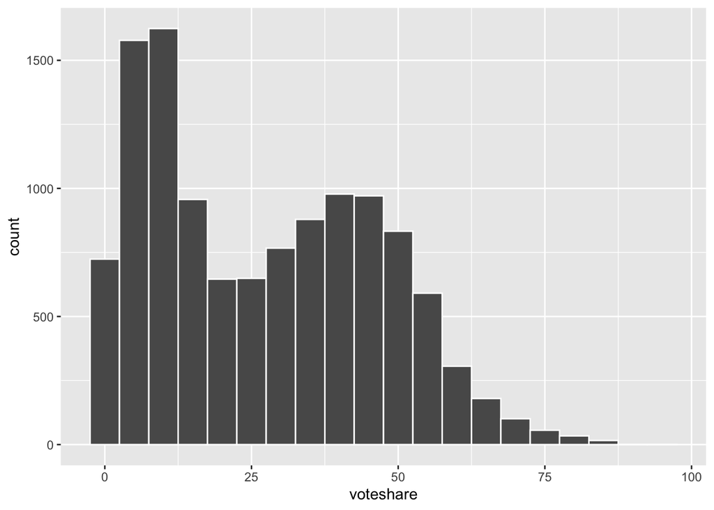

```r
hist_plot1 <- df %>%
  ggplot() +
  geom_histogram(aes(x = voteshare),
                 color = "white",
                 binwidth = 5)
hist_plot1
```

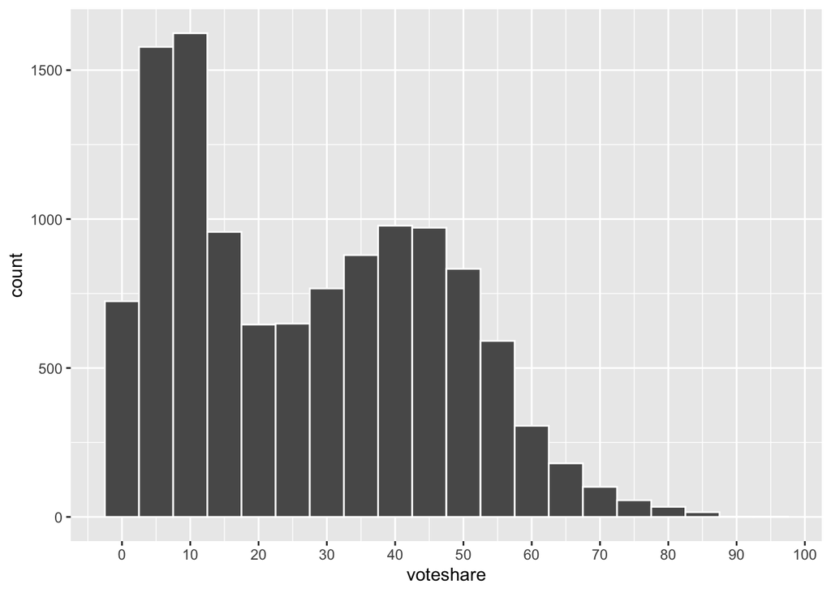

```r
hist_plot2 <- hist_plot1 +
  scale_x_continuous(breaks = seq(0, 100, by = 10),
                     labels = seq(0, 100, by = 10))
hist_plot2
```

## 2.4 Add another dimension

- When you want to add another dimension, you have two ways of getting it done.

#### (1) `facet_wrap(~)`

- Let’s add another dimension, `ldp`, to the histogram above by using `facet_wrap(~)`

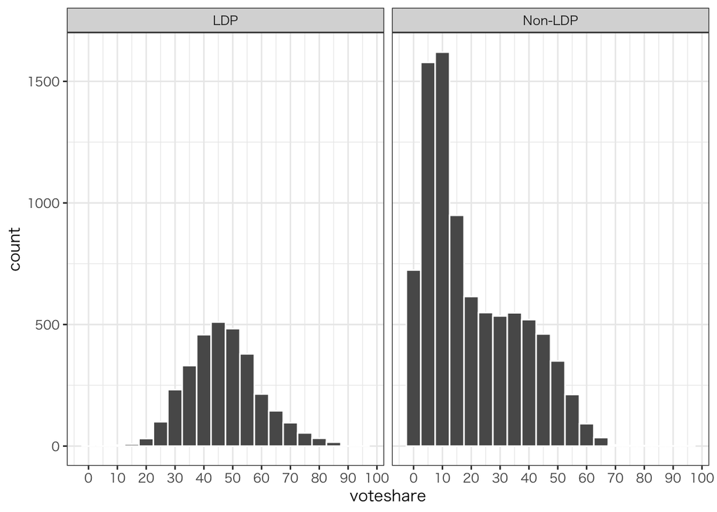

```r
hist_plot2 +
  facet_wrap(~ldp) +
  theme_bw(base_family = "HiraKakuProN-W3")
```

#### (2) fill = ….

- Let’s add another dimension, `ldp`, to the histogram above by using `fill = ...`
- You need to add `position = "identity"`

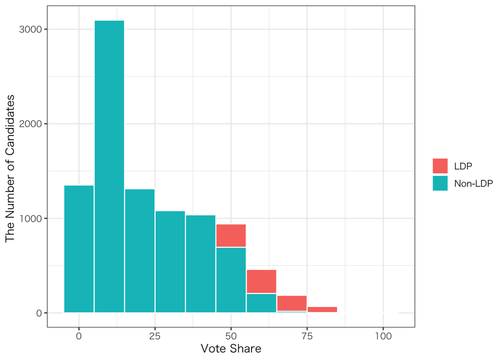

```r
df %>%
  mutate(ldp = if_else(seito == "自民", "LDP", "Non-LDP")) %>%
   ggplot() +
   geom_histogram(aes(x = voteshare,
                      fill = ldp),
                  position = "identity",
                  binwidth = 10,
                  color = "white") +
   labs(x = "Vote Share",
        y = "The Number of Candidates ",
        fill = "") +
  theme_bw(base_family = "HiraKakuProN-W3")
```

##### Solution:

- Using `alpha = ...`, you can make the bars transparent  
  ・`alpha = 0`・・・transparent  
  ・`alpha = 1`・・・not transparent
- Let’s set as `alpha = 0.5` here

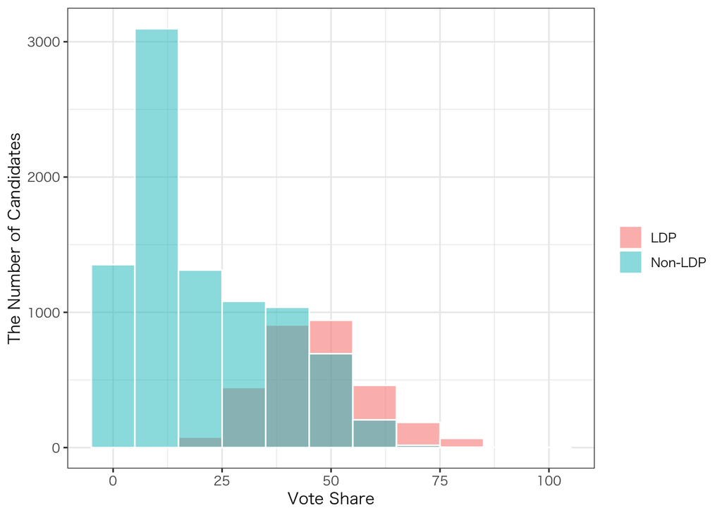

```r
df %>%
  mutate(ldp = if_else(seito == "自民", "LDP", "Non-LDP")) %>%
   ggplot() +
   geom_histogram(aes(x = voteshare,
                      fill = ldp),
                  position = "identity",
                  binwidth = 10,
                  color = "white",
                  alpha = 0.5) +
   labs(x = "Vote Share",
        y = "The Number of Candidates",
        fill = "") +
  theme_bw(base_family = "HiraKakuProN-W3")
```

##### You had better not do this!!

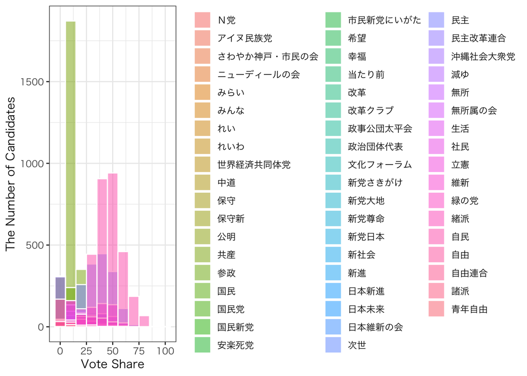

```r
df %>%
   ggplot() +
   geom_histogram(aes(x = voteshare,
                      fill = seito),
                  position = "identity",
                  binwidth = 10,
                  color = "white",
                  alpha = 0.5) +
   labs(x = "Vote Share",
        y = "The Number of Candidates",
        fill = "") +
  theme_bw(base_family = "HiraKakuProN-W3")
```

- You have too much information to figure it out.

##### Solution:

- Reduce the number of parties, say 3 parties.

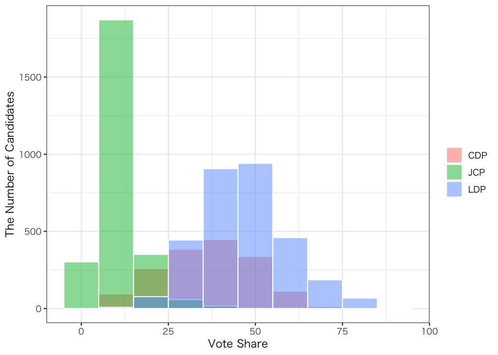

```r
df %>%
  filter(seito == "自民"|seito == "共産"|seito == "民主") %>%
  mutate(party = case_when(seito == "自民" ~ "LDP",
                           seito == "共産" ~ "JCP",
                           seito == "民主" ~ "CDP")) |>
   ggplot() +
   geom_histogram(aes(x = voteshare,
                      fill = party),
                  position = "identity",
                  binwidth = 10,
                  color = "white",
                  alpha = 0.5) +
   labs(x = "Vote Share",
        y = "The Number of Candidates",
        fill = "") +
  theme_bw(base_family = "HiraKakuProN-W3")
```

- This looks a lot better now — much easier to read!
- Delete `position = "identity"`, then you can add up each distribution in one bar

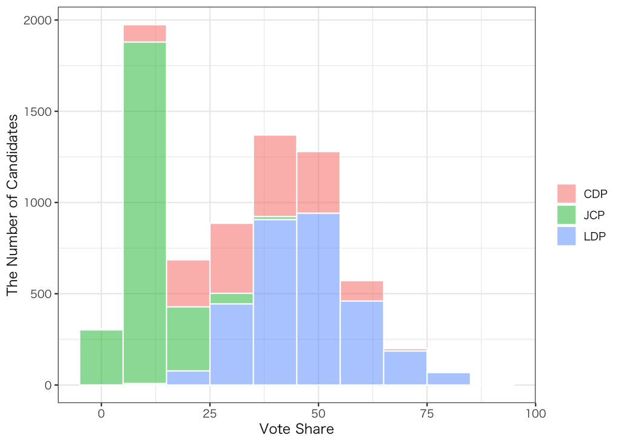

```r
df %>%
  filter(seito == "自民"|seito == "共産"|seito == "民主") %>%
  mutate(party = case_when(seito == "自民" ~ "LDP",
                           seito == "共産" ~ "JCP",
                           seito == "民主" ~ "CDP")) |>
   ggplot() +
   geom_histogram(aes(x = voteshare,
                      fill = party),
                  binwidth = 10,
                  color = "white",
                  alpha = 0.5) +
   labs(x = "Vote Share",
        y = "The Number of Candidates",
        fill = "") +
  theme_bw(base_family = "HiraKakuProN-W3")
```

- If you want to overlup the 3 distribution in one facet, then you should use `geom_density()` instead of `geom_histogram()`

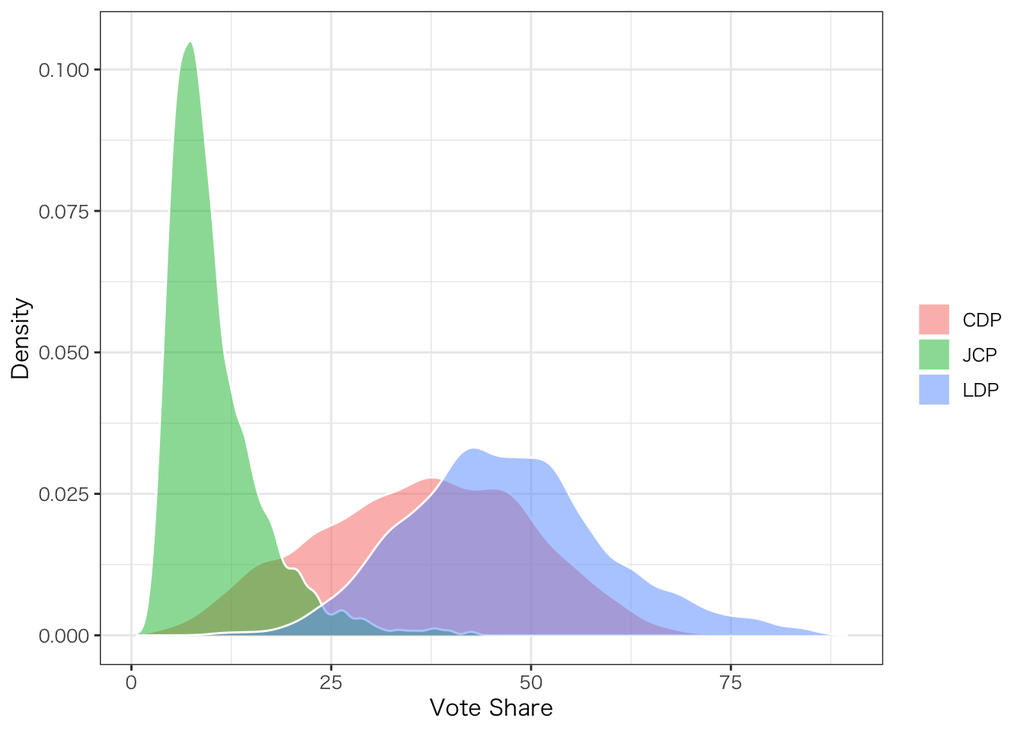

```r
df %>%
  filter(seito == "自民"|seito == "共産"|seito == "民主") %>%
  mutate(party = case_when(seito == "自民" ~ "LDP",
                           seito == "共産" ~ "JCP",
                           seito == "民主" ~ "CDP")) |>
   ggplot() +
   geom_density(aes(x = voteshare,
                      fill = party),
                  color = "white",
                  alpha = 0.5,
                adjust = 0.8) +
   labs(x = "Vote Share",
        y = "Density",
        fill = "") +
  theme_bw(base_family = "HiraKakuProN-W3")
```

- I like this graph the best — it’s the easiest to read.

# 3 Exercise

- **Q3.1**:  
  In reference to `2.4 Add another dimension`, draw a histogram of vote share (**voteshare**) for the LDP (Liberal Democratic Party) and CDP (Constitutional Democratic Party) candidates in the 2021 lower house election.  
  ・You see the party name in variable, **seito** in `hr96_21.csv`  
  ・You need to use `geom_histogram()` to draw a histogram.  
  ・You need to pay attention to the hidden values behind the bars in drawing a histogram.
- **Q3.2**:  
  In reference to `2.4 Add another dimension`, draw a histogram of vote share (**voteshare**) for the LDP (Liberal Democratic Party) and CDP (Constitutional Democratic Party) and JCP (Japan Communist Party) candidates in the 2021 lower house election.  
  ・You see the party name in variable, **seito** in `hr96_21.csv`  
  ・You need to use `geom_histogram()` to draw a histogram.  
  ・You need to pay attention to the hidden values behind the bars in drawing a histogram.

In answering **Q3.1** and **Q3.2** questions, use hr96-26.csv  
・`hr96_21.csv` is a collection of Japanese lower house election data covering 9 national elections (1996, 2000, 2003, 2005, 2009, 2012, 2014, 2017, 2021)  
・You need the following three variables which are included in `hr96_21.csv` to draw histograms:

| variable | detail |
| --- | --- |
| year | Election year (1996-2021) |
| voteshare | Vote share (%) |
| seito | Candidate’s affiliated party (in Japanese) |

・`hr96_21.csv` contains the following 23 variables:

| variable | detail |
| --- | --- |
| year | Election year (1996-2021) |
| pref | Prefecture |
| ku | Electoral district name |
| kun | Number of electoral district |
| rank | Ascending order of votes |
| wl | 0 = loser / 1 = single-member district (smd) winner / 2 = zombie winner |
| nocand | Number of candidates in each district |
| seito | Candidate’s affiliated party (in Japanese) |
| j_name | Candidate’s name (Japanese) |
| name | Candidate’s name (English) |
| previous | Previous wins |
| gender | Candidate’s gender:“male”, “female” |
| age | Candidate’s age |
| exp | Election expenditure (yen) spent by each candidate |
| status | 0 = challenger / 1 = incumbent / 2 = former incumbent |
| vote | votes each candidate garnered |
| voteshare | Vote share (%) |
| eligible | Eligible voters in each district |
| turnout | Turnout in each district (%) |
| castvote | Total votes cast in each district |
| seshu_dummy | 0 = Not-hereditary candidates, 1 = hereditary candidate |
| jiban_seshu | Relationship between candidate and his predecessor |
| nojiban_seshu | Relationship between candidate and his predecessor |

**References**

[Tidy Animated Verbs](https://github.com/gadenbuie/tidyexplain?fbclid=IwAR3Zt0pQZa0IEvP-1gstatQ42VM5yJZvw2vUaFEqt_m2smUgtZpTqvuurLJ6z0)

[宋財泫「ミクロ政治データ分析実習（2022年度）」](https://www.jaysong.net/micro-book/)

[土井翔平（北海道大学公共政策大学院）「Rで計量政治学入門」](https://shohei-doi.github.io/quant_polisci/data-import.html)

[矢内勇生（高知工科大学）授業一覧](http://yukiyanai.github.io/teaching/)

浅野正彦, 矢内勇生.『Rによる計量政治学』オーム社、2018年

浅野正彦, 中村公亮.『初めてのRStudio』オーム社、2018年

Kieran Healy, DATA VISUALIZATION, Princeton, 2019

Kosuke Imai, Quantitative Social Science: An Introduction, Princeton University Press, 2017